# Stock Market Portfolio Optimisation

```python
# Using the yfinance API to collect stock market data
pip install yfinance
```

```python
import pandas as pd
import yfinance as yf
from datetime import date, timedelta
```

```python
endDate = date.today().strftime("%Y-%m-%d")
startDate = (date.today() - timedelta(days=365)).strftime("%Y-%m-%d")
```

```python
tickers = ['AAPL', 'META', 'NVDA', 'GOOGL', 'AMZN']
```

```python
data = yf.download(tickers, start = startDate, end = endDate, progress=False)
```

```python
data = data.reset_index()
dataMelted = data.melt(id_vars=['Date'], var_name=['Attribute', 'Ticker'])
dataPivoted = dataMelted.pivot_table(index=['Date', 'Ticker'], columns='Attribute', values='value', aggfunc='first')
stockData = dataPivoted.reset_index()

print(stockData.tail())
```

```
Attribute       Date Ticker   Adj Close       Close        High         Low  \
1250      2024-07-30   AAPL  217.639999  217.639999  220.324997  217.335007
1251      2024-07-30   AMZN  181.809998  181.809998  185.860001  181.500000
1252      2024-07-30  GOOGL  169.389999  169.389999  171.229904  169.110001
1253      2024-07-30   META  464.170013  464.170013  472.730011  463.250000
1254      2024-07-30   NVDA  104.597099  104.597099  111.989998  104.269997

Attribute        Open       Volume
1250       219.039993   12153991.0
1251       184.768997   12727673.0
1252       170.240005    4491332.0
1253       467.000000    3529893.0
1254       111.510002  151940135.0
```

```python
import matplotlib.pyplot as plt
import seaborn as sns
```

```python
stockData['Date'] = pd.to_datetime(stockData['Date'])
stockData.set_index('Date', inplace = True)
stockData.reset_index(inplace = True)
plt.figure(figsize = (14,7))
sns.set(style='whitegrid')
```

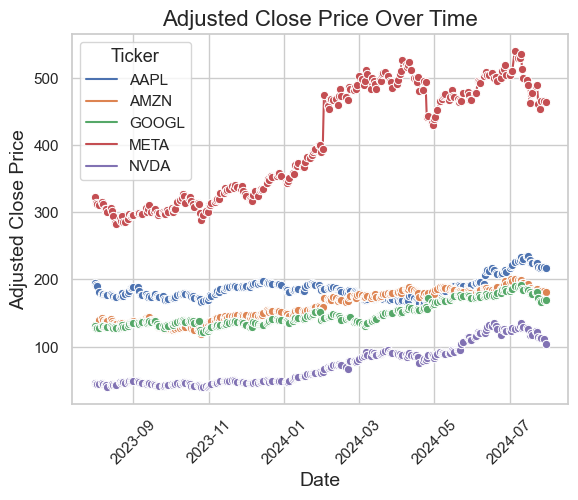

```python
sns.lineplot(data=stockData, x='Date', y='Adj Close', hue='Ticker', marker='o')

plt.title('Adjusted Close Price Over Time', fontsize=16)
plt.xlabel('Date', fontsize=14)
plt.ylabel('Adjusted Close Price', fontsize=14)
plt.legend(title='Ticker', title_fontsize='13', fontsize='11')
plt.grid(True)

plt.xticks(rotation=45)

plt.show()
```

The above graph displays the adjusted closed price of the 5 stocks we are analysing (AAPL, AMZN, GOOGL, META, NVIDIA) over time from July 2023 to July 2024. META has the highest adjusted closed price followed by AAPL, AMZN, GOOGL and finally NVDA.

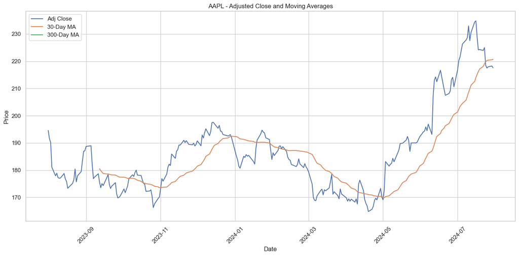

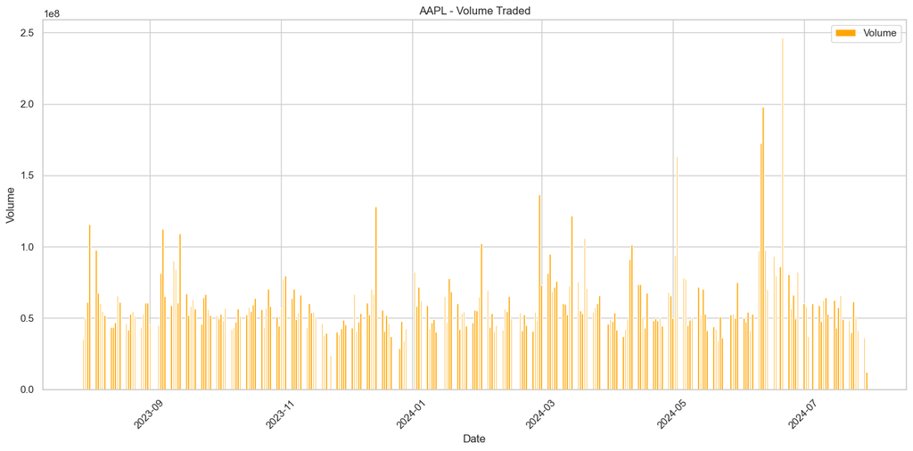

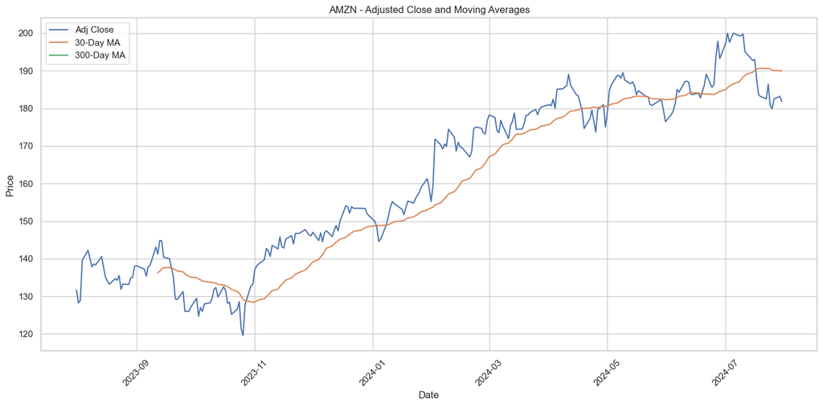

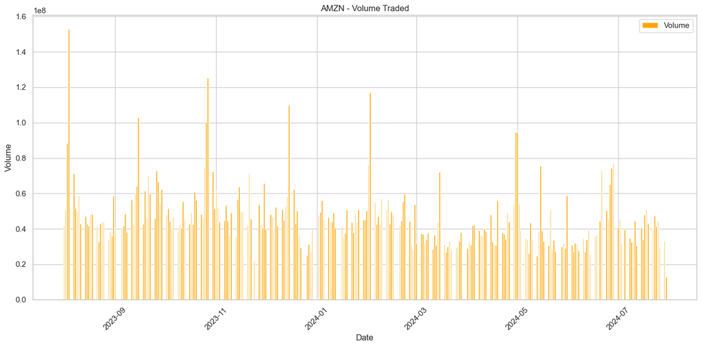

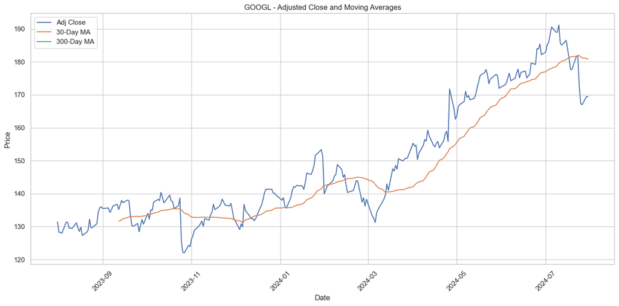

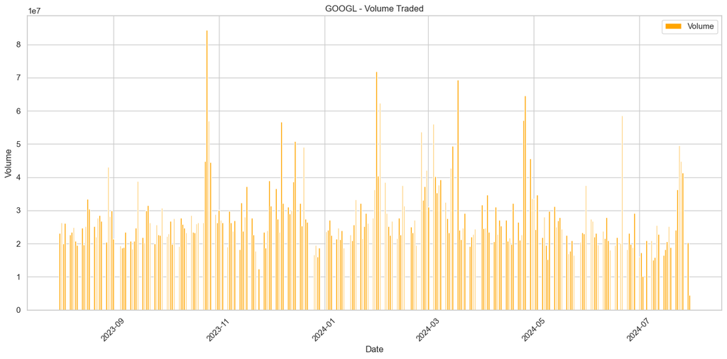

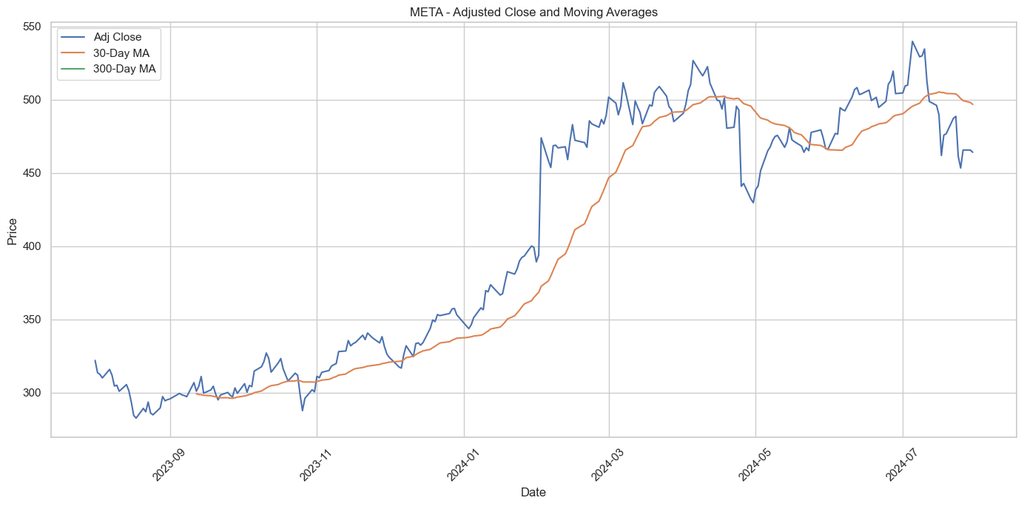

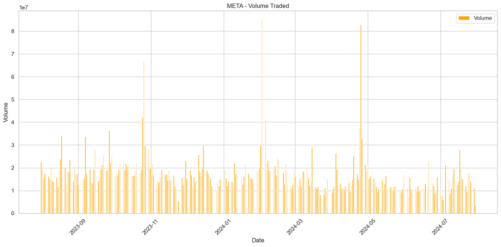

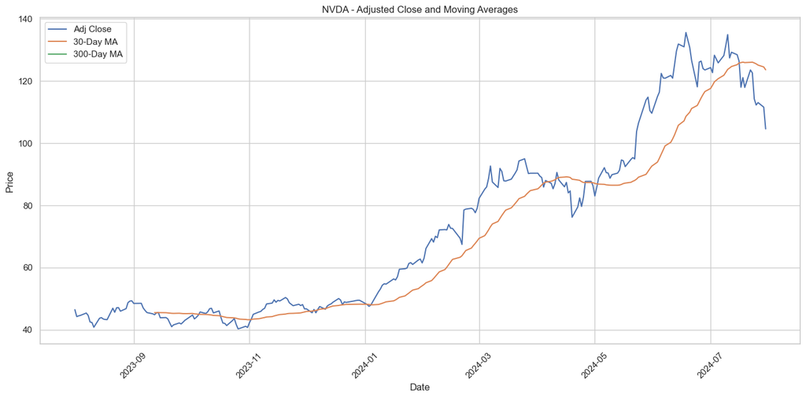

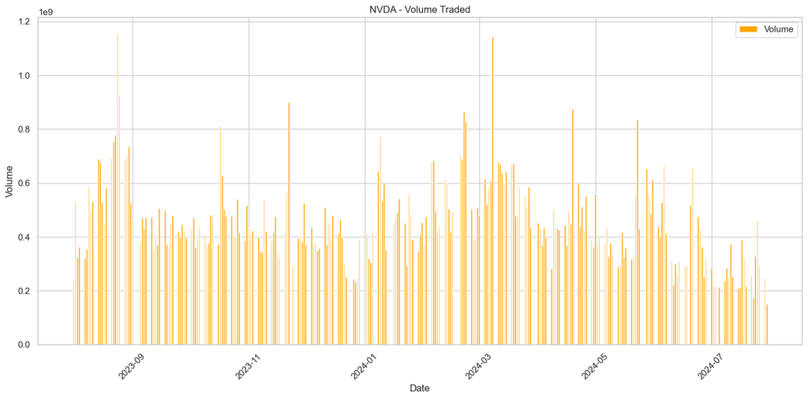

```python
shortWindow = 30
longWindow = 300
stockData.set_index('Date', inplace = True)
uniqueTickers = stockData['Ticker'].unique()

for ticker in uniqueTickers:
    tickerData = stockData[stockData['Ticker'] == ticker].copy()
    tickerData['30_MA'] = tickerData['Adj Close'].rolling(window=shortWindow).mean()
    tickerData['300_MA'] = tickerData['Adj Close'].rolling(window=longWindow).mean()

    plt.figure(figsize=(14, 7))
    plt.plot(tickerData.index, tickerData['Adj Close'], label='Adj Close')
    plt.plot(tickerData.index, tickerData['30_MA'], label='30-Day MA')
    plt.plot(tickerData.index, tickerData['300_MA'], label='300-Day MA')
    plt.title(f'{ticker} - Adjusted Close and Moving Averages')
    plt.xlabel('Date')
    plt.ylabel('Price')
    plt.legend()
    plt.grid(True)
    plt.xticks(rotation=45)
    plt.tight_layout()
    plt.show()

    plt.figure(figsize=(14, 7))
    plt.bar(tickerData.index, tickerData['Volume'], label='Volume', color='orange')
    plt.title(f'{ticker} - Volume Traded')
    plt.xlabel('Date')
    plt.ylabel('Volume')
    plt.legend()
    plt.grid(True)
    plt.xticks(rotation=45)
    plt.tight_layout()
    plt.show()
```

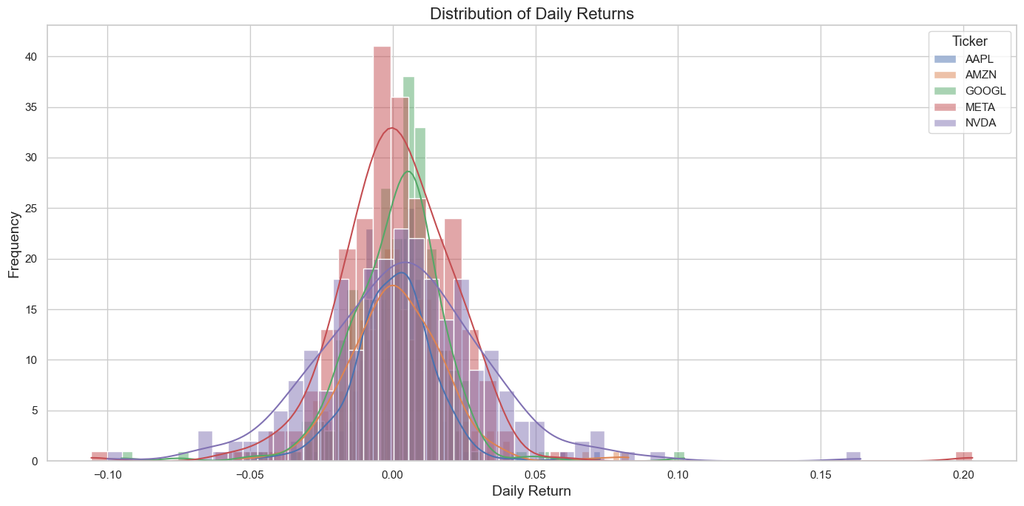

```python
stockData['Daily Return'] = stockData.groupby('Ticker')['Adj Close'].pct_change()
plt.figure(figsize=(14, 7))
sns.set(style='whitegrid')

for ticker in uniqueTickers:
    tickerData = stockData[stockData['Ticker'] == ticker]
    sns.histplot(tickerData['Daily Return'].dropna(), bins=50, kde=True, label=ticker, alpha=0.5)

plt.title('Distribution of Daily Returns', fontsize=16)
plt.xlabel('Daily Return', fontsize=14)
plt.ylabel('Frequency', fontsize=14)
plt.legend(title='Ticker', title_fontsize='13', fontsize='11')
plt.grid(True)
plt.tight_layout()
plt.show()
```

The distributions are approximately normal, centred around zero, which indicates that most daily returns are close to the average return. There are tails on both sides which reflects significant gains or losses.

NVDIA and META shows a wider distribution, which suggests a higher volatility compared to the other stocks.

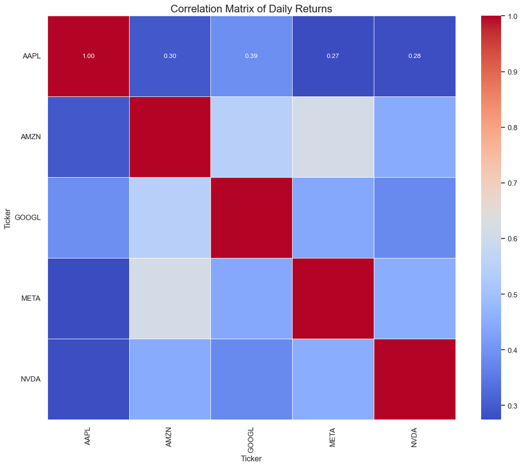

```python
dailyReturns = stockData.pivot_table(index='Date', columns='Ticker', values='Daily Return')

correlationMatrix = dailyReturns.corr()

plt.figure(figsize=(12, 10))
sns.set(style='whitegrid')

sns.heatmap(correlationMatrix, annot=True, cmap='coolwarm', linewidths=.5, fmt='.2f', annot_kws={"size": 10})
plt.title('Correlation Matrix of Daily Returns', fontsize=16)
plt.xticks(rotation=90)
plt.yticks(rotation=0)
plt.tight_layout()
plt.show()
```

Correlation represents the defree of which a pair of variables are related. The above correlation matrix displays how much each stock correlate to each other in pairs.

As discovered in the above correlation matrix, META and AMZN seem to have the highest correlation compared to any other stock in our study, indicating that they tend to move in the same direction.

There are also multiple low correlation pairs such as, META and AAPL, NVDA and AAPL.

These varying correlations suggest potential diversification benefits; combining stocks with lower correlation can reduce the overall portfolio risk.

```python
import numpy as np

# 252 because there are 252 trading days a year
expectedReturns = dailyReturns.mean() * 252
volatility = dailyReturns.std() * np.sqrt(252)

stockStats = pd.DataFrame({
    'Expected Return': expectedReturns,
    'Volatility': volatility
})

stockStats
```

| Ticker | Expected Return | Volatility |
| --- | --- | --- |
| AAPL | 0.138580 | 0.227412 |
| AMZN | 0.363243 | 0.277230 |
| GOOGL | 0.294154 | 0.275740 |
| META | 0.433580 | 0.366092 |
| NVDA | 0.928531 | 0.472629 |

NVDA has the highest expected return at an astonishing 92.85%, but a volatility of 47.26%, the highest amongst all the studied stocks, indicating a potentially high-risk investment with a relatively higher risk.

META and AMZN also have relatively high expected returns at 43.36% and 36.32% respectively but also a moderate volatility of 36.61% and 27.72% respectively.

GOOGL has a similar volatility compared to AMZN (27.57% GOOGL vs 27.72% AMZN) but has a lower expected return compared to AMZN (29.42% GOOGL vs 36.32% AMZN).

Whereas, AAPL has the lowest expected return of 13.86% but also has the lowest volatility at 22.74%.

After analysing the above, NVDA could potentially be the least attractive investment in terms of risk-adverse behaviour. Whereas AMZN in my opinion is the most attrative investment opportunity.

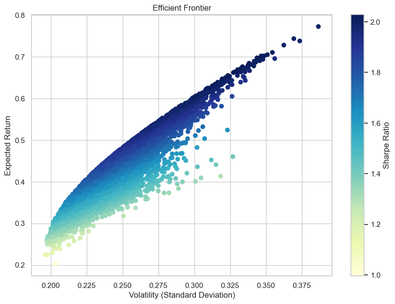

```python
def portfolioPerformance(weights, returns, covarianceMatrix):
    portfolioReturn = np.dot(weights, returns)
    portfolioVolatility = np.sqrt(np.dot(weights.T, np.dot(covarianceMatrix, weights)))
    return portfolioReturn, portfolioVolatility

numOfPortfolios = 10000

results = np.zeros((3, numOfPortfolios))

covarianceMatrix = dailyReturns.cov() * 252

np.random.seed(43)

for i in range(numOfPortfolios):
    weights = np.random.random(len(uniqueTickers))
    weights /= np.sum(weights)

    portfolioReturn, portfolioVolatility = portfolioPerformance(weights, expectedReturns, covarianceMatrix)

    results[0,i] = portfolioReturn
    results[1,i] = portfolioVolatility
    results[2,i] = portfolioReturn / portfolioVolatility  # Sharpe Ratio

plt.figure(figsize=(10, 7))
plt.scatter(results[1,:], results[0,:], c=results[2,:], cmap='YlGnBu', marker='o')
plt.title('Efficient Frontier')
plt.xlabel('Volatility (Standard Deviation)')
plt.ylabel('Expected Return')
plt.colorbar(label='Sharpe Ratio')
plt.grid(True)
plt.show()
```

Sharpe ratio is a measure of risk-adjusted returns.

Each dot represent a simulated portfolio and the colour represents the Sharpe Ratio, the darker the colour the better the risk-adjusted returns.

Portfolios on the leftmost edge (closer to the y-axis) offer the highest expected returns for a given level of volatility, which is the idea investment strategy when considering the Moden Portfolio Theory

```python
maxSharpeIdx = np.argmax(results[2])
maxSharpeReturn = results[0, max_sharpe_idx]
maxSharpeVolatility = results[1, max_sharpe_idx]
maxSharpeRatio = results[2, max_sharpe_idx]

maxSharpeReturn, maxSharpeVolatility, maxSharpeRatio
```

[output not shown]

The above shows that the a portfolio with maximum Sharpe ratio has the following:

Expected Return = 69.74% Volatility = 34.38% Sharpe Ratio ~ 2.0286

Identifying the weight of the stocks in a portfolio to achieve the following Sharpe Ratio are calculated below.

```python
maxSharpeWeights = np.zeros(len(uniqueTickers))

for i in range(numOfPortfolios):
    weights = np.random.random(len(uniqueTickers))
    weights /= np.sum(weights)

    portfolioReturn, portfolioVolatility = portfolioPerformance(weights, expectedReturns, covarianceMatrix)

    if results[2, i] == maxSharpeRatio:
        maxSharpeWeights = weights
        break

portfolioWeightsDF = pd.DataFrame({
    'Ticker': uniqueTickers,
    'Weight': maxSharpeWeights
})

portfolioWeightsDF
```

|  | Ticker | Weight |
| --- | --- | --- |
| 0 | AAPL | 0.298070 |
| 1 | AMZN | 0.010378 |
| 2 | GOOGL | 0.162567 |
| 3 | META | 0.212919 |
| 4 | NVDA | 0.316066 |